# Lab 7: Inference for Categorical DataR

Daniel Deneau

2021-06-26

```r
library(tidyverse)
library(openintro)
```

### Exercise 1

These percentages appear to be sample statistics derived from the data sample provided WIN-Gallup

### Exercise 2

We must assume that the sampling method was random, and each sample was done independently. This does seem reasonable to do with polls.

### Exercise 3

Each row in table 6 corresponds to a different country. Each row of atheism. Each row of the atheism table corresponds to an individual response by someone to the question of whether or not they are atheist.

```r
download.file("http://www.openintro.org/stat/data/atheism.RData", destfile = "atheism.RData")
load("atheism.RData")
atheism
```

```
##                  nationality    response year
## 1                Afghanistan non-atheist 2012
## 2                Afghanistan non-atheist 2012
## 3                Afghanistan non-atheist 2012
## 4                Afghanistan non-atheist 2012
## 5                Afghanistan non-atheist 2012
## 6                Afghanistan non-atheist 2012
## 7                Afghanistan non-atheist 2012
## 8                Afghanistan non-atheist 2012
## 9                Afghanistan non-atheist 2012
## 10               Afghanistan non-atheist 2012
## 11               Afghanistan non-atheist 2012
## 12               Afghanistan non-atheist 2012
## 13               Afghanistan non-atheist 2012
## 14               Afghanistan non-atheist 2012
```

[output cut: 33320 more lines]

### Exercise 4

The calculated proportion is: 0.05

The table shows the percentage of convinced atheists in the US to be 5%. so they do agree.

```r
us12 <- subset(atheism, nationality == "United States" & year == "2012")

us12_ath <- subset(us12, response=='atheist')
count(us12_ath) / count(us12)
```

```
##           n
## 1 0.0499002
```

### Exercise 5

First the samples must be random and independent, which they are since the poll was done randomly. Second, the success-failure criteria must be met:

```r
p = count(us12_ath)/count(us12)
n = count(us12)
n * p
```

```
##    n
## 1 50
```

```r
n * (1 - p)
```

```
##     n
## 1 952
```

Which they are.

### Exercise 6

```r
inference(us12$response, est = "proportion", type = "ci", method = "theoretical",
          success = "atheist")
```

```
## Single proportion -- success: atheist
## Summary statistics:
```

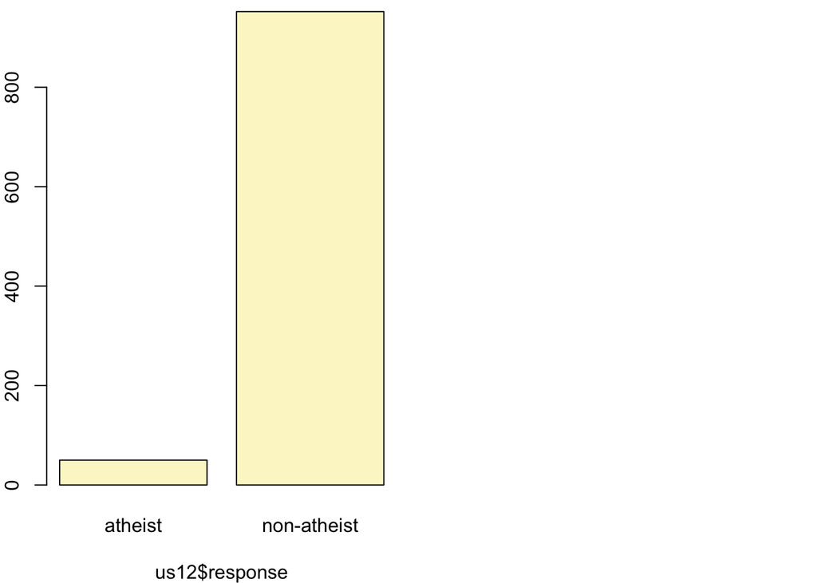

```
## p_hat = 0.0499 ;  n = 1002
## Check conditions: number of successes = 50 ; number of failures = 952
## Standard error = 0.0069
## 95 % Confidence interval = ( 0.0364 , 0.0634 )
```

The Margin of error is: 0.01 or 1%

```r
(1.95 * 0.0069)
```

```
## [1] 0.013455
```

### Exercise 7

For both Italy and Germany, the sampling is assumed to be random and independent. The success-failure criteria for both countries are met as well.

```r
it12 <- subset(atheism, nationality == "Italy" & year == "2012")
ge12 <- subset(atheism, nationality == "Germany" & year == "2012")
it_ath = subset(it12, response=="atheist")
ge_ath = subset(ge12, response=="atheist")
p_i = count(it_ath)/count(it12)
p_g = count(ge_ath)/count(ge12)
p_i * count(it12)
```

```
##    n
## 1 79
```

```r
(1 - p_i) * count(it12)
```

```
##     n
## 1 908
```

```r
p_g * count(ge12)
```

```
##    n
## 1 75
```

```r
(1 - p_g) * count(ge12)
```

```
##     n
## 1 427
```

```r
inference(it12$response, est = "proportion", type = "ci", method = "theoretical",
          success = "atheist")
```

```
## Single proportion -- success: atheist
## Summary statistics:
```

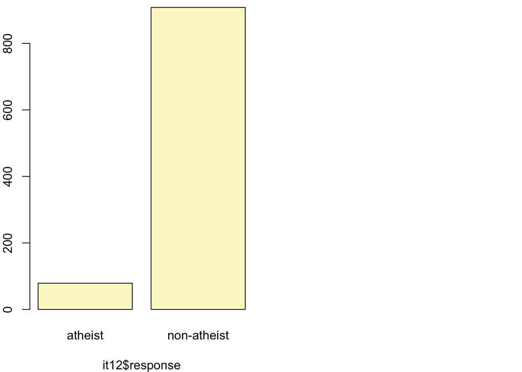

```
## p_hat = 0.08 ;  n = 987
## Check conditions: number of successes = 79 ; number of failures = 908
## Standard error = 0.0086
## 95 % Confidence interval = ( 0.0631 , 0.097 )
```

```r
inference(ge12$response, est = "proportion", type = "ci", method = "theoretical",
          success = "atheist")
```

```
## Single proportion -- success: atheist
## Summary statistics:
```

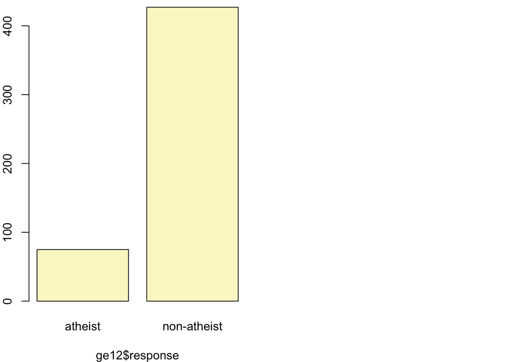

```
## p_hat = 0.1494 ;  n = 502
## Check conditions: number of successes = 75 ; number of failures = 427
## Standard error = 0.0159
## 95 % Confidence interval = ( 0.1182 , 0.1806 )
```

```r
0.0086 * 1.95
```

```
## [1] 0.01677
```

```r
0.0159 * 1.95
```

```
## [1] 0.031005
```

### Exercise 8

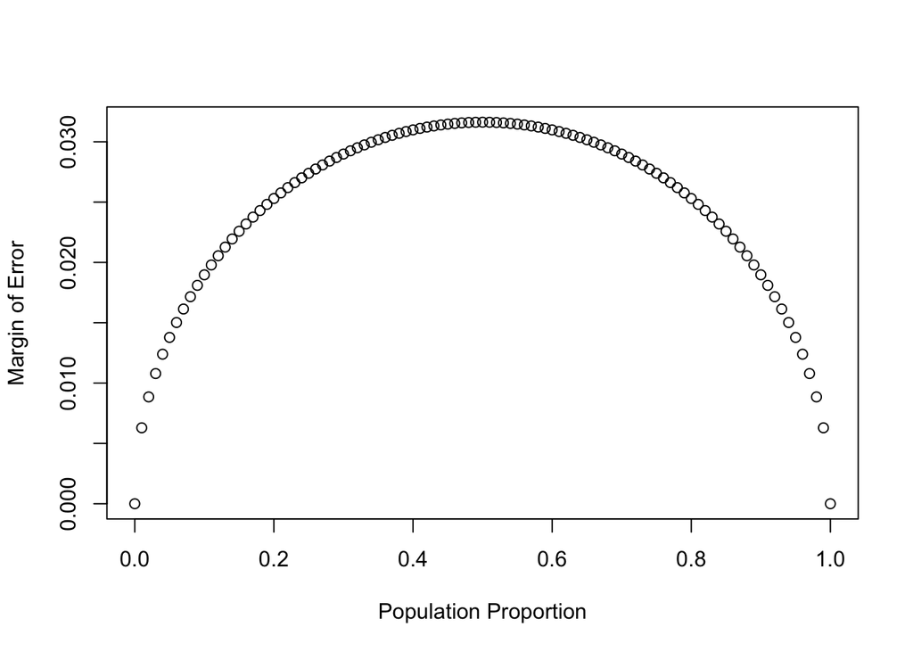

```r
n <- 1000
p <- seq(0, 1, 0.01)
me <- 2 * sqrt(p * (1 - p)/n)
plot(me ~ p, ylab = "Margin of Error", xlab = "Population Proportion")
```

### Exercise 9

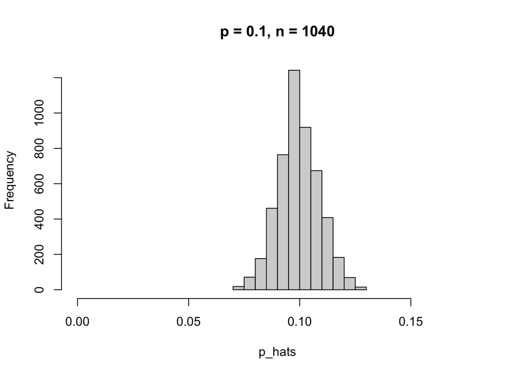

```r
p <- 0.1
n <- 1040
p_hats <- rep(0, 5000)

for(i in 1:5000){
  samp <- sample(c("atheist", "non_atheist"), n, replace = TRUE, prob = c(p, 1-p))
  p_hats[i] <- sum(samp == "atheist")/n
}

hist(p_hats, main = "p = 0.1, n = 1040", xlim = c(0, 0.18))
```

```r
summary(p_hats)
```

```
##    Min. 1st Qu.  Median    Mean 3rd Qu.    Max.
## 0.07019 0.09327 0.09904 0.09969 0.10577 0.12981
```

### Exercise 10

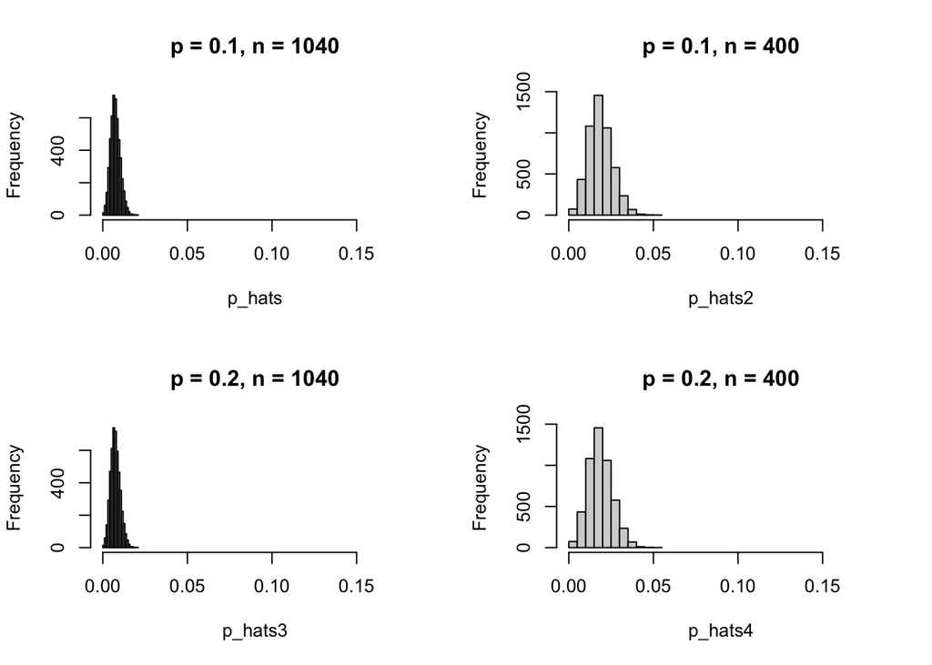

```r
p <- 0.1
n <- 1040
p_hats <- rep(0, 5000)

p_2 <- 0.1
n_2 <- 400
p_hats2 <- rep(0, 5000)

p_3 <- 0.02
n_3 <- 1040
p_hats3 <- rep(0, 5000)

p_4 <- 0.02
n_4 <- 400
p_hats4 <- rep(0, 5000)


for(i in 1:5000){
  samp <- sample(c("atheist", "non_atheist"), n, replace = TRUE, prob = c(p, 1-p))
  samp <- sample(c("atheist", "non_atheist"), n_2, replace = TRUE, prob = c(p_2, 1-p_2))
  samp <- sample(c("atheist", "non_atheist"), n_3, replace = TRUE, prob = c(p_3, 1-p_3))
  samp <- sample(c("atheist", "non_atheist"), n_4, replace = TRUE, prob = c(p_4, 1-p_4))
  p_hats[i] <- sum(samp == "atheist")/n
  p_hats2[i] <- sum(samp == "atheist")/n_2
  p_hats3[i] <- sum(samp == "atheist")/n_3
  p_hats4[i] <- sum(samp == "atheist")/n_4
}

par(mfrow = c(2, 2))
hist(p_hats, main = "p = 0.1, n = 1040", xlim = c(0, 0.18))
hist(p_hats2, main = "p = 0.1, n = 400", xlim = c(0, 0.18))
hist(p_hats3, main = "p = 0.2, n = 1040", xlim = c(0, 0.18))
hist(p_hats4, main = "p = 0.2, n = 400", xlim = c(0, 0.18))
```

### Exercise 11

Yes, because the distributions appear to be close to normal.

### OYO 1

1. Null Hypothesis: Spain has seen no change in its atheism index between 2005 and 2012 Alt Hypothesis: Spain has seen some change in its atheism index between 2005 and 2012. The poll was random and independent, and the success-failure criteria are me:

```r
sp12 <- subset(atheism, nationality == "Spain" & year == "2012")

sp12_ath = subset(sp12, response=="atheist")

sp05 <- subset(atheism, nationality == "Spain" & year == "2005")

sp05_ath = subset(sp05, response=="atheist")

p_s = count(sp12_ath)/count(sp12)

p_s * count(sp12)
```

```
##     n
## 1 103
```

```r
(1 - p_s) * count(sp12)
```

```
##      n
## 1 1042
```

```r
p_s05 = count(sp05_ath)/count(sp05)

p_s05 * count(sp05)
```

```
##     n
## 1 115
```

```r
(1 - p_s05) * count(sp05)
```

```
##      n
## 1 1031
```

The confidence levels do overlap quite a bit, therefore we can not reject the null hypothesis. There is not convincing evidence that Spain has seen a change.

```r
inference(sp12$response, est = "proportion", type = "ci", method = "theoretical",
          success = "atheist")
```

```
## Single proportion -- success: atheist
## Summary statistics:
```

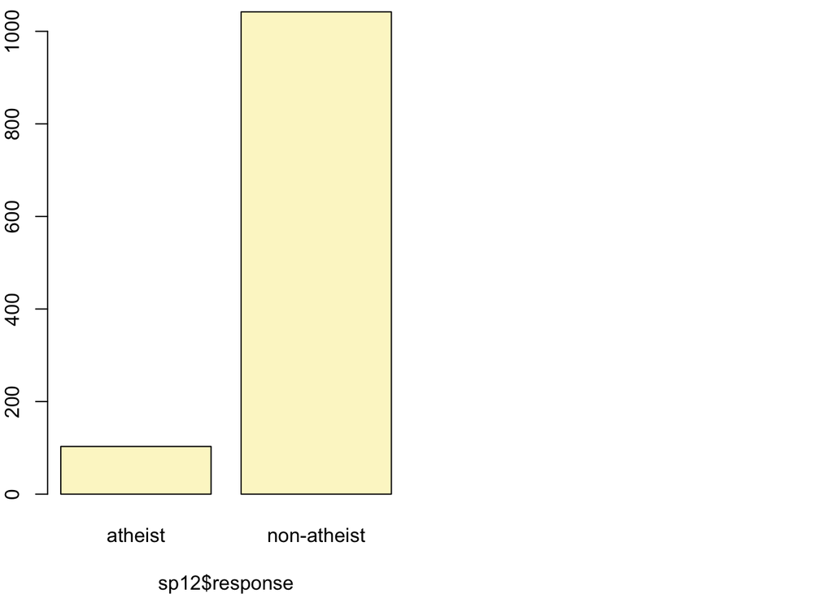

```
## p_hat = 0.09 ;  n = 1145
## Check conditions: number of successes = 103 ; number of failures = 1042
## Standard error = 0.0085
## 95 % Confidence interval = ( 0.0734 , 0.1065 )
```

```r
inference(sp05$response, est = "proportion", type = "ci", method = "theoretical",
          success = "atheist")
```

```
## Single proportion -- success: atheist
## Summary statistics:
```

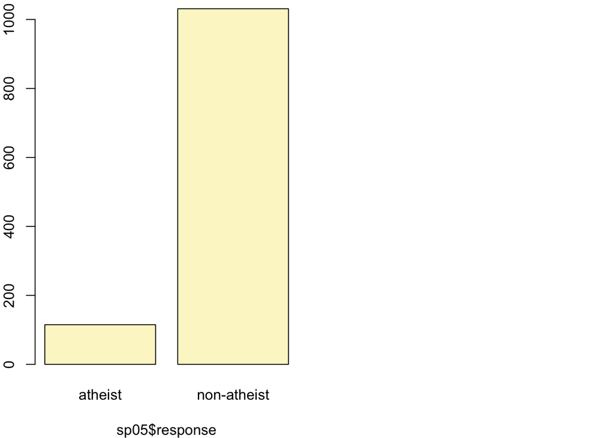

```
## p_hat = 0.1003 ;  n = 1146
## Check conditions: number of successes = 115 ; number of failures = 1031
## Standard error = 0.0089
## 95 % Confidence interval = ( 0.083 , 0.1177 )
```

2. Null Hypothesis: The United States has seen no change in its atheism index between 2005 and 2012 Alt Hypothesis: The United States has seen some change in its atheism index between 2005 and 2012. The poll was random and independent, and the success-failure criteria are me:

```r
us12 <- subset(atheism, nationality == "United States" & year == "2012")

us12_ath = subset(us12, response=="atheist")

us05 <- subset(atheism, nationality == "United States" & year == "2005")

us05_ath = subset(us05, response=="atheist")

p_u = count(sp12_ath)/count(sp12)

p_u * count(us12)
```

```
##          n
## 1 90.13624
```

```r
(1 - p_u) * count(us12)
```

```
##          n
## 1 911.8638
```

```r
p_u05 = count(us05_ath)/count(us05)

p_u05 * count(us05)
```

```
##    n
## 1 10
```

```r
(1 - p_u) * count(sp05)
```

```
##         n
## 1 1042.91
```

The confidence levels do not overlap quite at all, therefore we can reject the null hypothesis. There is convincing evidence that the United States has seen a change.

```r
inference(us12$response, est = "proportion", type = "ci", method = "theoretical",
          success = "atheist")
```

```
## Single proportion -- success: atheist
## Summary statistics:
```

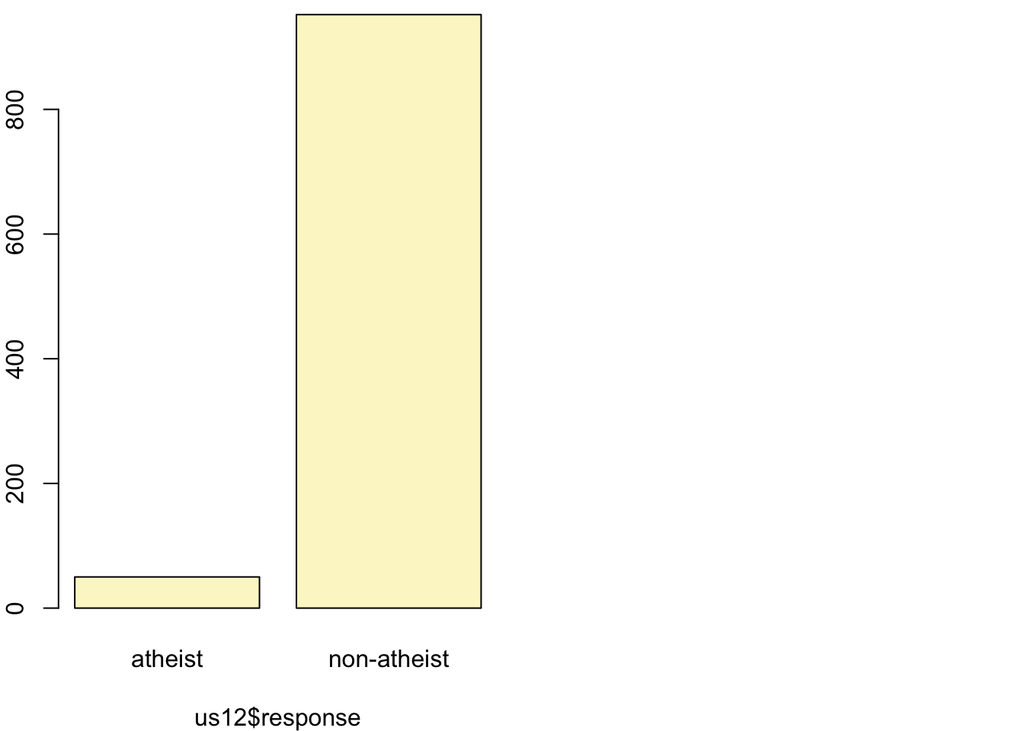

```
## p_hat = 0.0499 ;  n = 1002
## Check conditions: number of successes = 50 ; number of failures = 952
## Standard error = 0.0069
## 95 % Confidence interval = ( 0.0364 , 0.0634 )
```

```r
inference(us05$response, est = "proportion", type = "ci", method = "theoretical",
          success = "atheist")
```

```
## Single proportion -- success: atheist
## Summary statistics:
```

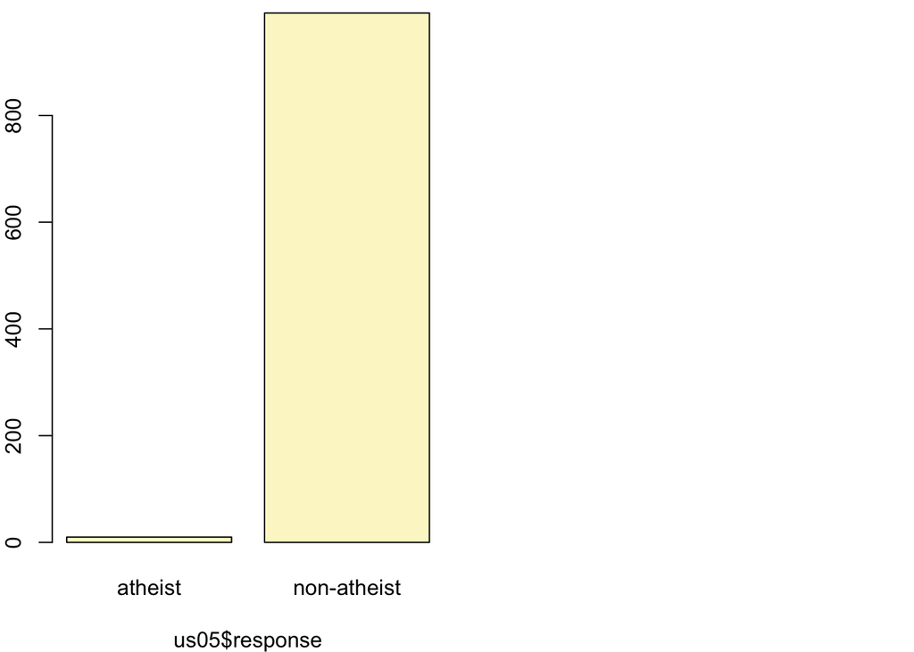

```
## p_hat = 0.01 ;  n = 1002
## Check conditions: number of successes = 10 ; number of failures = 992
## Standard error = 0.0031
## 95 % Confidence interval = ( 0.0038 , 0.0161 )
```

### OYO 2

A type 1 error would be rejecting the null hypothesis that there is no change, when there is. With 39 countries, I would expect to detect a change in 2 countries by chance, at a signifiance level of 0.05.

```r
0.05 * 39
```

```
## [1] 1.95
```

### OYO 3

We would have to calculate the sample size from the standard error and population proportion, which is assumed to be 0.5.

```r
p = 0.5
m_error = 0.01
z = 1.95

standard_error = m_error/z

n = (p*p) / standard_error^2
n
```

```
## [1] 9506.25
```

So n must be at least n = 9506.25 n = 9507